# Indian economy in pixels

Abhishek Sharma

02/11/2022

# **Abstract**

This study combines information obtained on more than 1000 businesses over a two-decade period in order to show how a certain sector of the Indian economy has evolved. The data contains crucial firm-level variables such as sales and total assets.

# **Data Description**

This dataset includes financial information about firms from 2001 through 2022. We won’t look at every type of company. We will instead focus on big businesses that aren’t substantially influenced by the government. To this end, this dataset excludes:

1. businesses that are government-owned
2. firms that have either sales or total assets less than 10 crore
3. mining and construction firms
4. financial firms( Are excluded due to capital controls imposed on these firms by the government )
5. firms that are not listed on either the NSE or the BSE

In order to describe firm specific characteristics, we will use the following seven attributes from the dataset.

1. company name
2. incorporation year: The age and birth cohort of a firms are proxied by the year of incorporation
3. financial year:The year for which the company’s financial information is recorded
4. sales: The revenue of the firm
5. total assets: Is a proxy for the size of the firm
6. retained profits/losses for the year
7. industry sector

# **Introduction**

India’s economy has one of the fastest growth rates in the world. Therefore, it is reasonable to believe that firm profits have only increased over time. It is also reasonable to assume that more companies opened during this decade than during the preceding one. Sales and overall assets should have increased year after year. However, are these speculations true?

In this project, we will try to shed light on these assumptions using data collected from the CMIE prowess database.

## As a first step, let’s visualize two attributes of ‘RELIANCE INDUSTRIES LTD.’

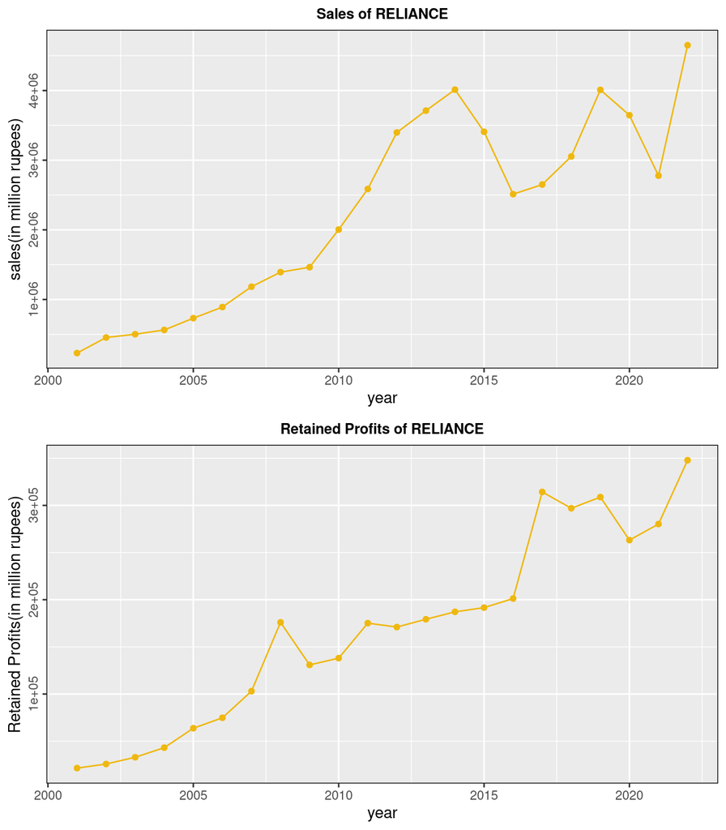

## According to our dataset, the number of firms in each year has remained almost constant.

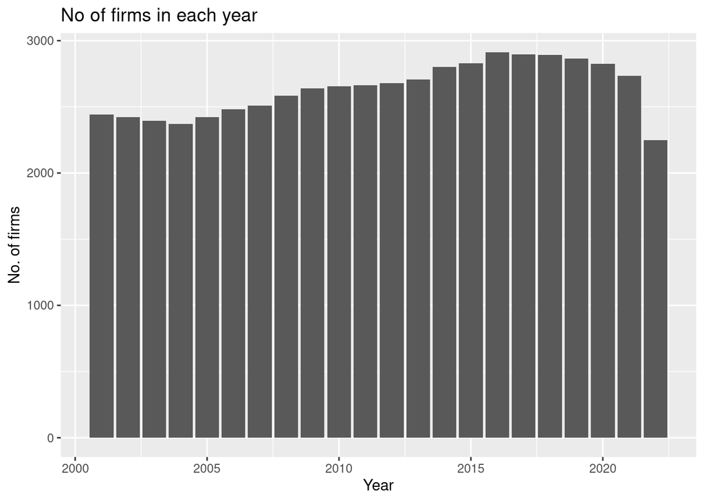

## According to our dataset, most companies were founded between 1975 and 2000. Moreover, more companies were founded in the last decade than in the current decade.

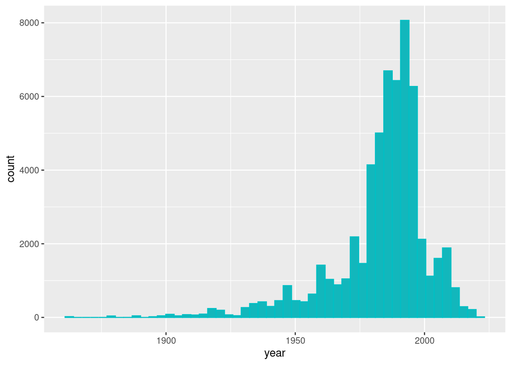

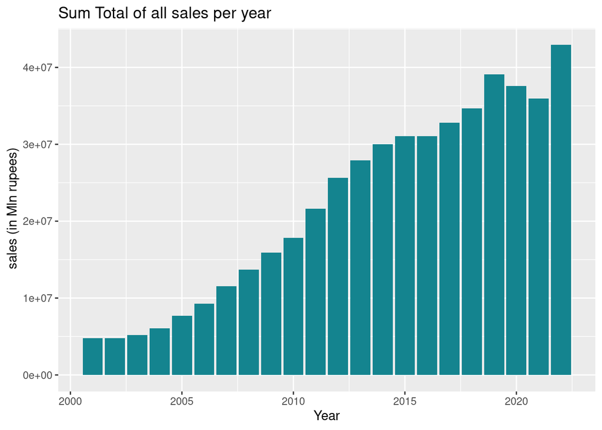

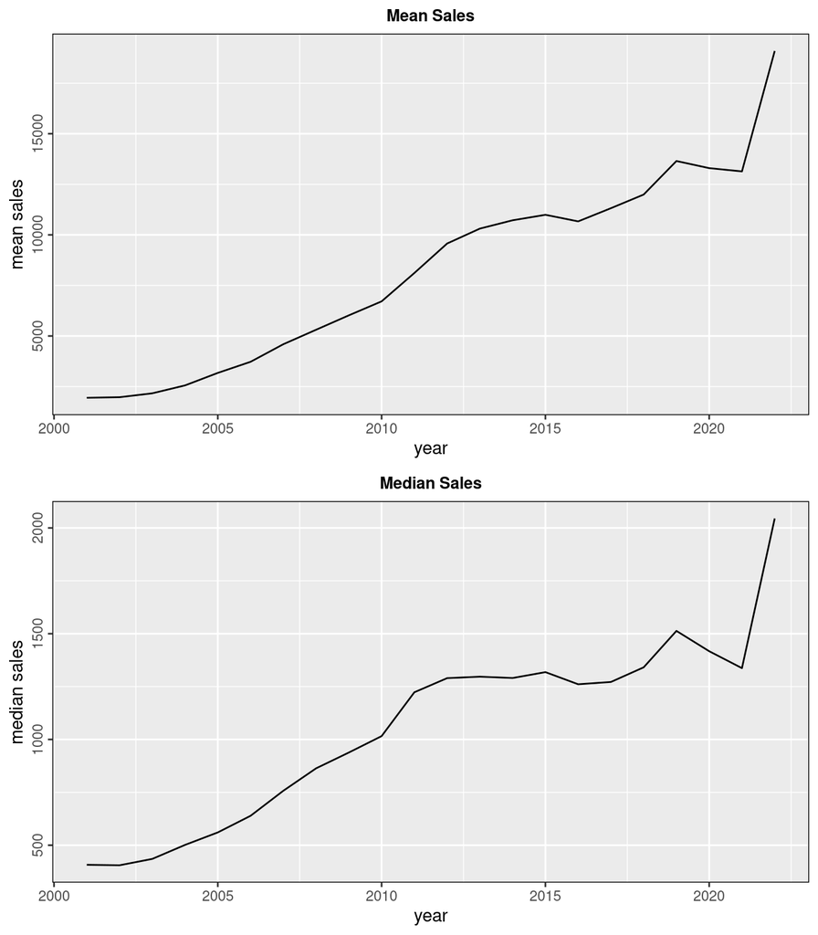

## Mean total assets of firms per year has increased constantly over the years. But this is not the case for median total assests of firms per year.

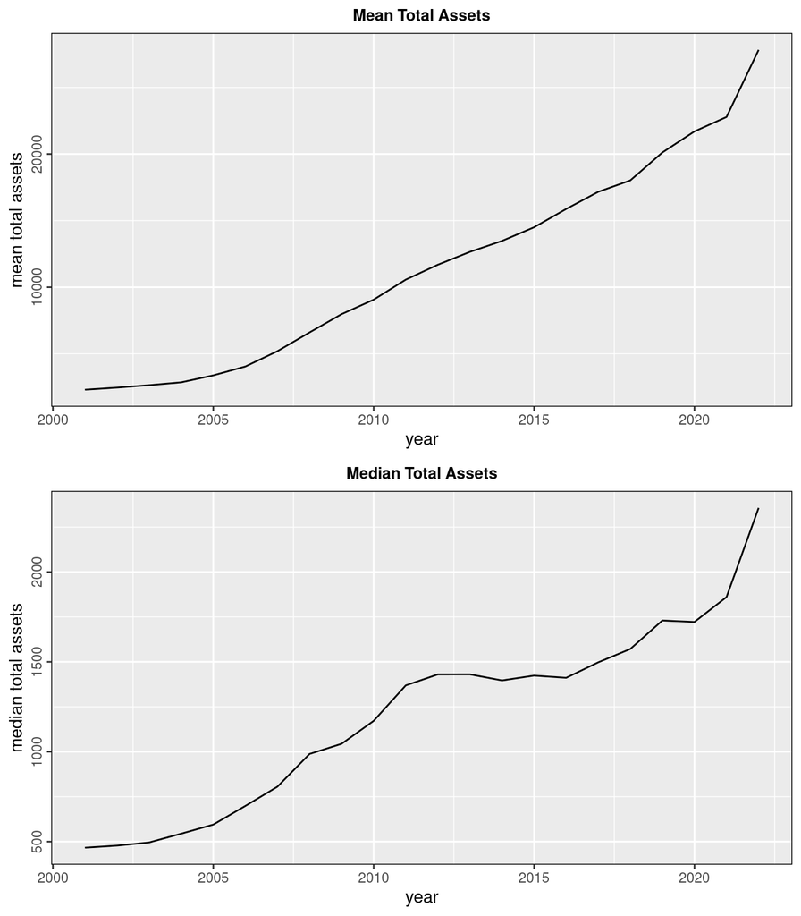

## The most profitable industry sectors are:

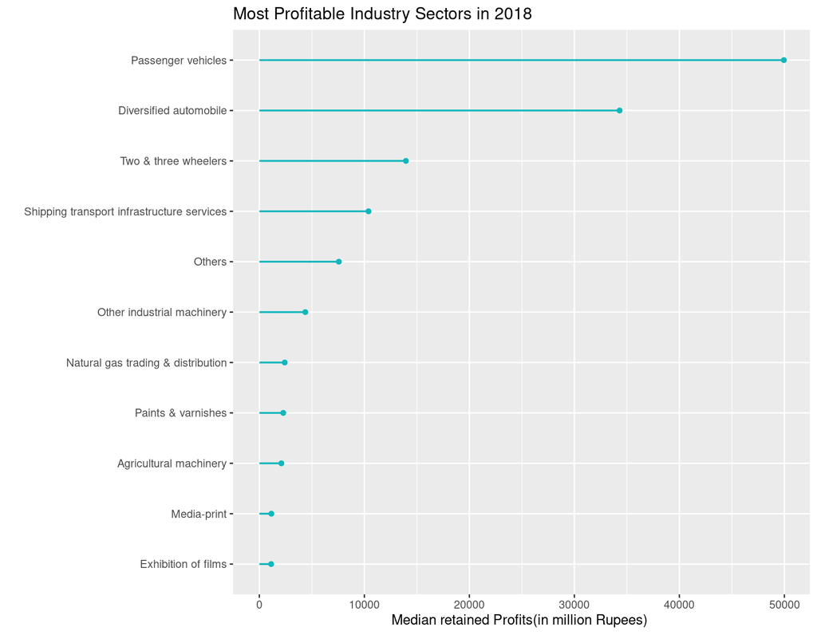

## Mean retained profits of firms each year saw a huge increase after the COVID pandemic.

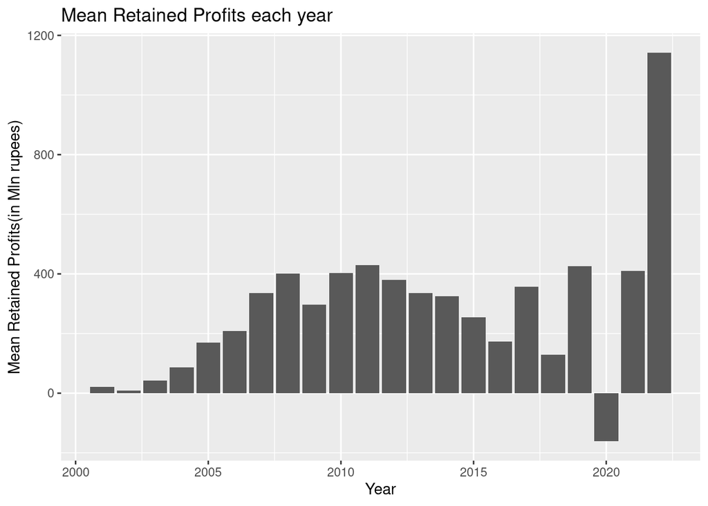

# **Conclusion**

In the analysis above, we attempted to present a broad overview of the development of the Indian economy.